# 1_使用Keras对FashionMNIST图片数据集进行简单分类

## 1_使用Keras对FashionMNIST图片数据集进行简单分类

- **标签**：图片分类、Keras、FashionMNIST
- **难度**：🌟🌟
- **参考**：https://www.tensorflow.org/tutorials/keras/basic_classification
- **协议**：MIT License

加载库，包括深度学习框架`keras`、用于数值计算的`numpy`、用于绘图的`matplotlib`

```python
import keras
from keras.datasets import fashion_mnist
import numpy as np
import matplotlib.pyplot as plt
%matplotlib inline
```

加载FashionMNIST数据，没有则自动下载

- 每张图片都是28*28像素
- 训练集共6W条，测试集共1W条，都使用三维数组表示，取值范围为0～255即像素值
- 标签共10类，从0～9分别表示T-shirt/top, Trouser, Pullover, Dress, Coat, Sandal, Shirt, Sneaker, Bag, Ankle boot

```python
(train_images, train_labels), (test_images, test_labels) = fashion_mnist.load_data()
class_names = ['T-shirt/top', 'Trouser', 'Pullover', 'Dress', 'Coat',
               'Sandal', 'Shirt', 'Sneaker', 'Bag', 'Ankle boot']
```

查看训练集和测试集的各项维度信息，展示训练集的第一张图片，对图片数据进行预处理

[output not shown]

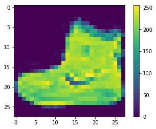

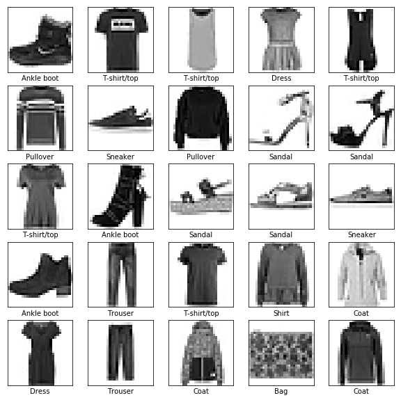

```python
print('Train Set Shape:', train_images.shape)
print('Train Set Number:', len(train_labels))
print(train_labels[:20])
print('Test Set Shape:', test_images.shape)
print('Test Set Number:', len(test_labels))

# 绘制训练集的第一张图片
plt.figure()
plt.imshow(train_images[0])
plt.colorbar()
plt.gca().grid(False)

# 绘制训练集的前25张图片
plt.figure(figsize=(10, 10))
for i in range(25):
    plt.subplot(5, 5, i + 1)
    plt.xticks([])
    plt.yticks([])
    plt.grid('off')
    plt.imshow(train_images[i], cmap=plt.cm.binary)
    plt.xlabel(class_names[train_labels[i]])

# 进行预处理，将取值范围归一化到0～1
train_images = train_images / 255.0
test_images = test_images / 255.0
```

定义模型并训练

- `Sequential`是keras中的序列模型，比较简单，从前往后不断加网络层即可
- `Flatten`表示把数据打平，`70000*28*28`对应的`input_shape`是`28,28`，打平之后数据的形状就变成了`70000*784`，即变成两维
- `Dense`即全连接层，加权相乘、偏置、激活函数，指定神经元的个数和所用的激活函数即可
- 使用`compile`编译模型，需指定优化算法optimizer、损失函数loss、性能指标metrics
- 使用`fit`训练模型，输入为训练集图片数据，输出为训练集标签，共训练5轮

```python
# 定义模型
model = keras.Sequential([
    keras.layers.Flatten(input_shape=(28, 28)),
    keras.layers.Dense(128, activation='relu'),
    keras.layers.Dense(10, activation='softmax')
])

# 编译模型
model.compile(optimizer='adam',
              loss='sparse_categorical_crossentropy',
              metrics=['accuracy'])

# 训练模型
model.fit(train_images, train_labels, epochs=5)
```

```
<keras.callbacks.History at 0x7fce838cf630>
```

```python
# 使用测试集图片数据和测试集标签评估模型
test_loss, test_acc = model.evaluate(test_images, test_labels)
print('Test Accuracy:', test_acc)

# 也可以使用模型根据测试集图片数据预测对应的标签
predictions = model.predict(test_images)
print(predictions[0])            # 10维概率分布
print(np.argmax(predictions[0])) # 概率最大的一维对应的下标，即预测的标签
print(test_labels[0])            # 真实的标签
```

```
Test Accuracy: 0.873
[9.74581326e-06 3.37983749e-07 5.07009474e-07 2.74243234e-07
 5.23984511e-07 2.31678843e-01 8.92923345e-06 1.21336944e-01
 1.24898419e-04 6.46839023e-01]
9
9
```

最后再展示一下模型在前25张测试图片上的预测结果

[figure not shown]

```python
plt.figure(figsize=(10, 10))
for i in range(25):
    plt.subplot(5, 5, i + 1)
    plt.xticks([])
    plt.yticks([])
    plt.grid('off')
    plt.imshow(test_images[i], cmap=plt.cm.binary)
    predicted_label = np.argmax(predictions[i])
    true_label = test_labels[i]
    if predicted_label == true_label:
        color = 'green'
    else:
        color = 'red'
    plt.xlabel("{} ({})".format(class_names[predicted_label],
                                class_names[true_label]),
                                color=color)
```